# Poll Paper

Public Opinion on Carbon Taxation

Keene Morrow

5/11/2021

*Find a poll that asks questions relevant to your policy area. Write a paper (no more than 600 words) summarizing and analyzing the results of the survey. What do the results suggest about public opinion on your policy? Has public opinion been changing? How is this likely to play into policy outcomes in your policy area? Be prepared to tell the class about the survey findings.*

In a March 2018 Gallup poll, 53% of the 1,041 respondents indicated that they were in favor of “passing a carbon tax to encourage reductions in carbon dioxide emissions.” (Figure 1, Gallup 2018)

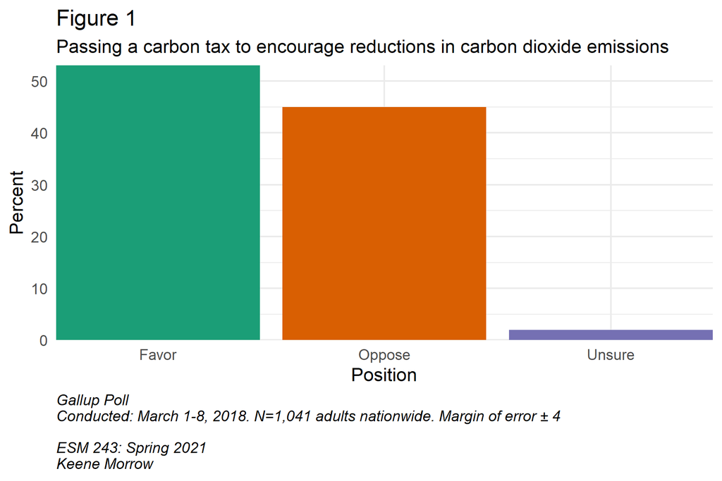

**References**

Gallup. 2018. “Americans’ Views on Environmental, Energy Policies (Trends)” https://news.gallup.com/poll/232016/americans-views-environmental-energy-policies-trends.aspx

Martin, R et al. 2014. “The impact of a carbon tax on manufacturing: evidence from microdata.” Journal of Public Economics, 117, 1-14. https://doi.org/10.1016/j.jpubeco.2014.04.016

Rott, Nathan. 2021. “Biden Moves to Have U.S. Rejoin Climate Accord. National Public Radio (NPR). https://www.npr.org/sections/inauguration-day-live-updates/2021/01/20/958923821/biden-moves-to-have-u-s-rejoin-climate-accord

Stiglitz, J. E. & Stern, N. 2017. Report of the High-Level Commission on Carbon Prices. World Bank.